# C8 Week 3

JAGV

2026-01-21

# Predicting with trees

## Key ideas

- Iteratively split variables into groups
- Evaluate “homogeneity” **within** each group
- Split again if necessary

### Pros

- Easy to interpret
- Better performance in non-linear settings

### Cons

- Without pruning/cross-validation can lead to **overfitting**
- Harder to estimate uncertainty
- Results may be variable

An example of a decision tree is here: [USA presidential election](http://graphics8.nytimes.com/images/2008/04/16/us/0416-nat-subOBAMA.jpg)

## Basic algorithm

1. Start with all variables in one group
2. Find the variable/split that best separates the outcomes
3. Divide the data into two gropus (*leaves*) on that split (*node*)
4. Within each split, find the best variable/split that separates the outcome
5. Continue until the groups are too small or sufficiently *pure* (homogeneous)

## Measures of impurity

In order to measure the homogeneity, we have some **measures of impurity**

$$\hat{p}_{mk} = \frac{1}{N_m}\sum_{x_i \in \text{Leaf}_m}I\left(y_i =
k\right)$$

where

- $\hat{p}_{mk}$ is the estimated probability of the objects in group $m$ to take on the classification $k$
- $m$ is the number of leaves
- $k$ is an index for the class
- $N_m$ is the number of objects in the leaf $m$
- $I\left(y_i=k\right)$ is the indicator function that counts the number of times that a particular class appears in the leaf $m$.

Then we have the following measures of impurity:

- **Misclassification error**:
  $$1 - \hat{p}_{mk\left(m\right)}$$
  where $k\left(m\right)$ stands for the most common $k$ (classification/group). Here
  - $0$ means *perfect purity*
  - $0.5$ means *no purity*
- **Gini index**:
  $$\sum_{k \neq k'}\hat{p}_{mk}\hat{p}_{mk'} =
  \sum_{k=1}^{m}\hat{p}_{mk}\left(1-\hat{p}_{mk}\right) =
  1-\sum_{k=1}^{m}\hat{p}_{mk}^2$$
  Here:
  - $0 =$ *perfect purity*
  - $0.5 =$ *no purity*
- **Deviance/information gain**:
  $$-\sum_{k=1}^{m}\hat{p}_{mk}log_{e}\left(\hat{p}_{mk}\right)
  \\
  -\sum_{k=1}^{m}\hat{p}_{mk}log_{2}\left(\hat{p}_{mk}\right)$$
  where base of the logarithm used in **deviance** is $e$ whereas for **information gain** is the number $2$

Let’s take a look at some examples. Here, imagine that we are dealing with a variable trying to **split the dots into blue and red dots**. Also, that we are on a leaf where 15 out of 16 dots are blue and 1 out of 16 are red.

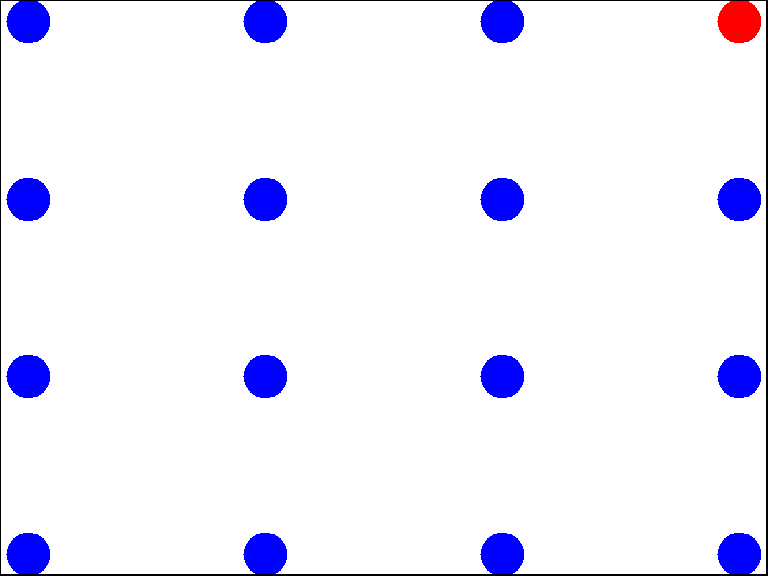

Here, the measures of impurity are calculated as follows:

- **Misclassification error**: $1 - \frac{15}{16} = \frac{1}{16} = 0.06$ (almost *perfect purity*)
- **Gini index**: $1 - \left[\left(\frac{1}{16}\right)^2 + \left(\frac{15}{16}\right)^2\right] = 0.12$
- **Information gain**: $-\left\{\frac{1}{16}\log_2\left(\frac{1}{16}\right) + \frac{15}{16}\log_2\left(\frac{15}{16}\right)\right\} = 0.34$

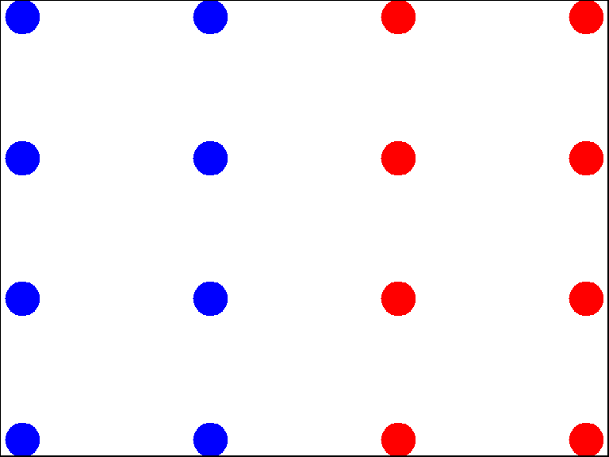

Here, the measures of impurity are calculated as follows:

- **Misclassification error**: $1 - \frac{1}{2} = \frac{1}{2} = 0.5$ (*no pure*)
- **Gini index**: $1 - \left[\left(\frac{1}{2}\right)^2 + \left(\frac{1}{2}\right)^2\right] = \frac{1}{2} = 0.5$
- **Information gain**: $-\left\{\frac{1}{2}\log_2\left(\frac{1}{2}\right) + \frac{1}{2}\log_2\left(\frac{1}{2}\right)\right\} = 1$

Let’s move to another example using the `iris` dataset

```r
data(iris)
library(ggplot2)
names(iris)
```

```
## [1] "Sepal.Length" "Sepal.Width"  "Petal.Length" "Petal.Width"  "Species"
```

```r
table(iris$Species)
```

```
##
##     setosa versicolor  virginica
##         50         50         50
```

### Create training and test sets

```r
library(caret)
inTrain <- createDataPartition(y = iris$Species, p = 0.7, list = FALSE)
training <- iris[inTrain,]
testing <- iris[-inTrain,]
dim(training)
```

```
## [1] 105   5
```

```r
dim(testing)
```

```
## [1] 45  5
```

### Plotting the sepal width versus petal width

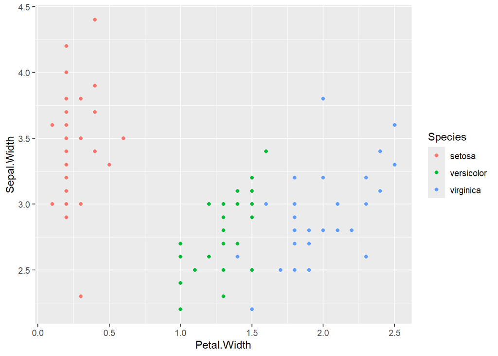

```r
qplot(Petal.Width, Sepal.Width, colour = Species, data = training)
```

Nice! We can see by the naked eye three clusters according to the Species.

```r
library(caret)
modFit <- train(Species ~ ., method = "rpart", data = training)
print(modFit$finalModel)
```

```
## n= 105
##
## node), split, n, loss, yval, (yprob)
##       * denotes terminal node
##
## 1) root 105 70 setosa (0.33333333 0.33333333 0.33333333)
##   2) Petal.Length< 2.35 35  0 setosa (1.00000000 0.00000000 0.00000000) *
##   3) Petal.Length>=2.35 70 35 versicolor (0.00000000 0.50000000 0.50000000)
##     6) Petal.Width< 1.65 38  3 versicolor (0.00000000 0.92105263 0.07894737) *
##     7) Petal.Width>=1.65 32  0 virginica (0.00000000 0.00000000 1.00000000) *
```

It is useful to plot the tree. Let’s do that

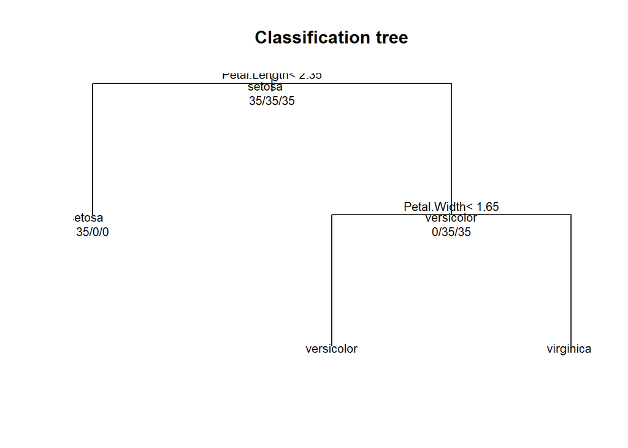

```r
plot(modFit$finalModel, uniform = TRUE, main = "Classification tree")
text(modFit$finalModel, use.n = TRUE, all = TRUE, cex= 0.8)
```

The tree is ugly (like me) so we can make a prettier plot.

```r
library(rattle)
```

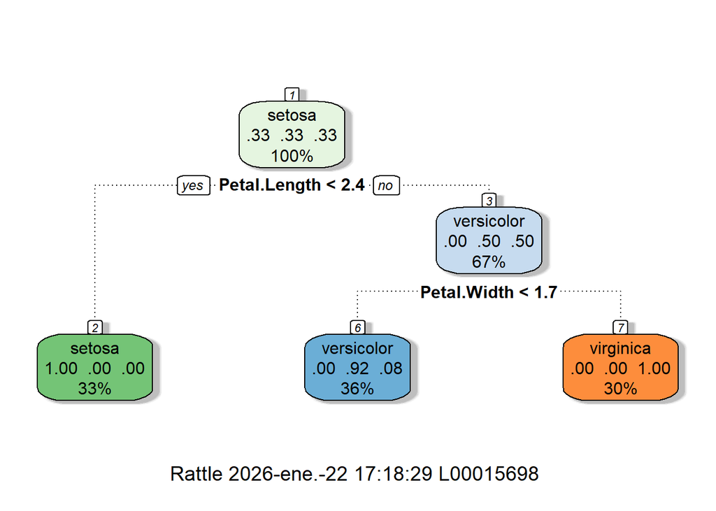

```r
fancyRpartPlot(modFit$finalModel)
```

### Predicting new values

```r
predict(modFit, newdata = testing)
```

```
##  [1] setosa     setosa     setosa     setosa     setosa     setosa
##  [7] setosa     setosa     setosa     setosa     setosa     setosa
## [13] setosa     setosa     setosa     versicolor versicolor versicolor
## [19] versicolor versicolor versicolor versicolor virginica  versicolor
## [25] versicolor virginica  versicolor versicolor versicolor versicolor
## [31] virginica  virginica  virginica  virginica  virginica  virginica
## [37] versicolor virginica  virginica  virginica  virginica  virginica
## [43] virginica  virginica  virginica
## Levels: setosa versicolor virginica
```

## Notes and further reading

- Classification trees are non-linear models
  - They use interactions between variables
  - Data transformations may be less important (monotone transformations)
  - Trees can also be used for regression problems (continuous outcome)
- Note that there are multiple tree building options in `R` both in `caret` package (`party`, `rpart`) and out of the `caret` package - `tree`
- [Introduction to statistical learning](http://www-bcf.usc.edu/~gareth/ISL/)
- [Elements of Statistical Learning](http://www-stat.stanford.edu/~tibs/ElemStatLearn/)
- [Classification and regression trees](http://www.amazon.com/Classification-Regression-Trees-Leo-Breiman/dp/0412048418)

# Bagging

## Introduction

Bootstrap Aggregating = Bagging. The basic idea is two fold:

- Resample cases and recalculate predictions
- Average or majority vote

Notes:

- Similar bias
- Reduced variance
- More useful for non-linear functions

```r
ozone <- read.table("https://web.stanford.edu/~hastie/ElemStatLearn/datasets/ozone.data", sep = '\t', header=TRUE)
ozone <- ozone[order(ozone$ozone),]
head(ozone)
```

```
##     ozone radiation temperature wind
## 17      1         8          59  9.7
## 19      4        25          61  9.7
## 14      6        78          57 18.4
## 45      7        48          80 14.3
## 106     7        49          69 10.3
## 7       8        19          61 20.1
```

The idea is to predict temperature in function of ozone.

## Bagged loess

The first thing to do is just show an example fo how this works

```r
ll <- matrix(NA, nrow = 10, ncol = 155)
for(i in 1:10){
    # Resampling. Indexes are stored at ss
    ss <- sample(1:dim(ozone)[1], replace = T)
    # Subset according to the indexes
    ozone0 <- ozone[ss,]
    # Reorder the ozone levels for this sample
    ozone0 <- ozone0[order(ozone0$ozone),]
    # Fit a loess curve (similar to spline)
    loess0 <- loess(temperature ~ ozone, data = ozone0, span = 0.2)
    ll[i,] <- predict(loess0, newdata = data.frame(ozone = 1:155))
}
```

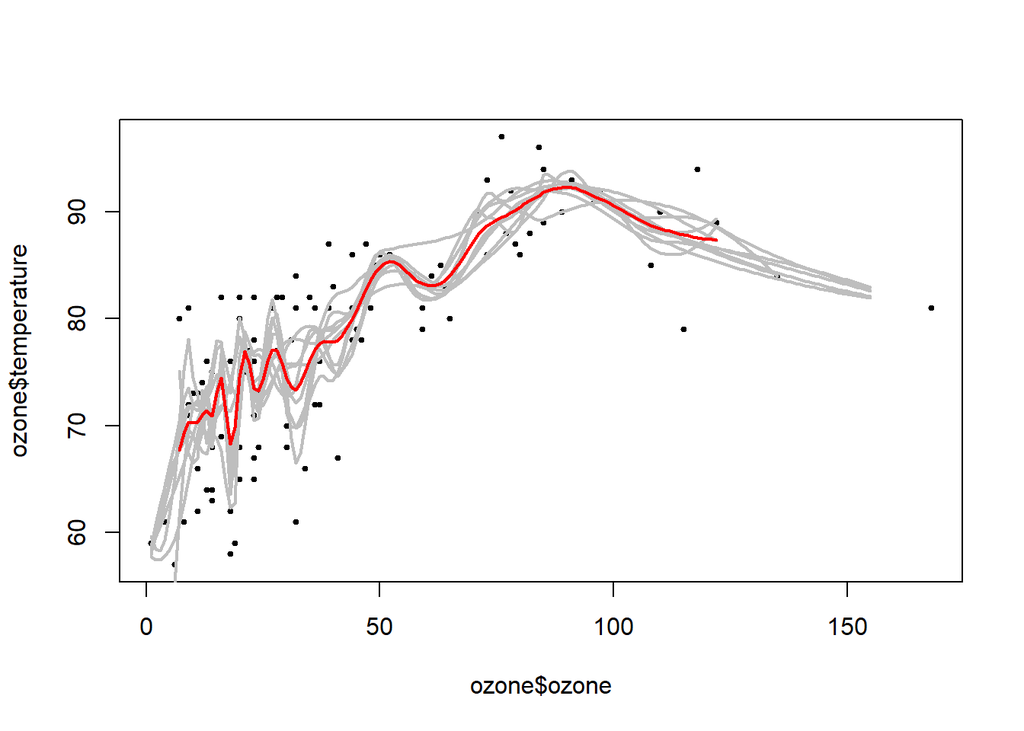

```r
plot(ozone$ozone, ozone$temperature, pch = 19, cex = 0.5)
for(i in 1:10){
    lines(1:155, ll[i,], col = "grey", lwd = 2)
}
lines(1:155, apply(ll,2,mean), col = "red", lwd = 2)
```

### Bagging in caret

Some models perform bagging for you (Thank God!). In `train` function consider `method` options: + `bagEarth` + `treebag` + `bagFDA`

Alternatively you can bag any model you choose using the `bag` function

An advanced use might looks like

```r
predictors <- data.frame(ozone = ozone$ozone)
temperature <- ozone$temperature
treebag <- bag(predictors, temperature, B = 10,
               bagControl = bagControl(fit = ctreeBag$fit,
                                       predict = ctreeBag$pred,
                                       aggregate = ctreeBag$aggregate))
```

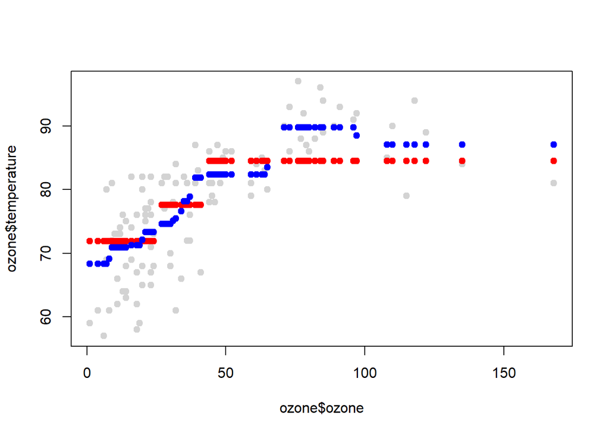

```r
plot(ozone$ozone, ozone$temperature, col = "lightgrey", pch = 19)
points(ozone$ozone, predict(treebag$fits[[1]]$fit,predictors), pch = 19, col = "red")
points(ozone$ozone, predict(treebag,predictors), pch = 19, col = "blue")
```

### Notes and further resources

- Bagging is most useful for non-linear models
- Often used with trees - an extension is *random forests*
- Several models use bagging in `caret`’s `train` function
- [Bagging](http://en.wikipedia.org/wiki/Bootstrap_aggregating)
- [Bagging and boosting](http://stat.ethz.ch/education/semesters/FS_2008/CompStat/sk-ch8.pdf)
- [Elements of Statistical Learning](http://www-stat.stanford.edu/~tibs/ElemStatLearn/)

# Random forests

## Basic ideas

1. Bootstrap samples
2. At each split, bootstrap variables
3. Grow multiple trees and vote

#### Pros

1. Accuracy

#### Cons

1. Speed: algorithm can be slow as it processes large number of trees)
2. Interpretability: it is hard to interpret as we have a large number of splits and nodes
3. Overfitting: it is difficult to know which tree is causing over-fitting
4. **Note**: it is **extremely important** to use cross-validation when running random forest algorithms

## Example: iris dataset

Let’s use the `iris` data set as an example

```r
data(iris)
library(ggplot2)
library(caret)
inTrain <- createDataPartition(y = iris$Species, p = 0.7, list = FALSE)
training <- iris[inTrain,]
testing <- iris[-inTrain,]

#### Fitting the model
modFit <- train(Species ~., data = training, method = "rf", prox = TRUE)
modFit
```

```
## Random Forest
##
## 105 samples
##   4 predictor
##   3 classes: 'setosa', 'versicolor', 'virginica'
##
## No pre-processing
## Resampling: Bootstrapped (25 reps)
## Summary of sample sizes: 105, 105, 105, 105, 105, 105, ...
## Resampling results across tuning parameters:
##
##   mtry  Accuracy   Kappa
##   2     0.9391459  0.9078010
##   3     0.9412797  0.9110235
##   4     0.9393836  0.9082542
##
## Accuracy was used to select the optimal model using the largest value.
## The final value used for the model was mtry = 3.
```

#### Getting a single tree

```r
library(randomForest)
getTree(modFit$finalModel,k=2)
```

```
##    left daughter right daughter split var split point status prediction
## 1              2              3         3        2.70      1          0
## 2              0              0         0        0.00     -1          1
## 3              4              5         3        4.80      1          0
## 4              6              7         4        1.65      1          0
## 5              8              9         4        1.70      1          0
## 6              0              0         0        0.00     -1          2
## 7              0              0         0        0.00     -1          3
## 8             10             11         3        4.95      1          0
## 9              0              0         0        0.00     -1          3
## 10             0              0         0        0.00     -1          2
## 11            12             13         2        2.65      1          0
## 12             0              0         0        0.00     -1          3
## 13            14             15         3        5.45      1          0
## 14             0              0         0        0.00     -1          2
## 15             0              0         0        0.00     -1          3
```

#### Class “centers”

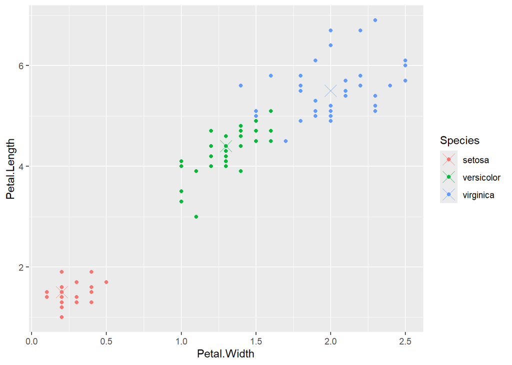

```r
irisP <- classCenter(training[,c(3,4)], training$Species, modFit$finalModel$prox)
irisP <- as.data.frame(irisP)
irisP$Species <- rownames(irisP)
p <- qplot(Petal.Width, Petal.Length, col = Species, data = training)
p + geom_point(aes(x = Petal.Width, y = Petal.Length, col = Species), size = 5, shape = 4, data = irisP)
```

#### Predicting new values

```r
pred <- predict(modFit, testing)
testing$predRight <- pred==testing$Species
table(pred,testing$Species)
```

```
##
## pred         setosa versicolor virginica
##   setosa         15          0         0
##   versicolor      0         13         0
##   virginica       0          2        15
```

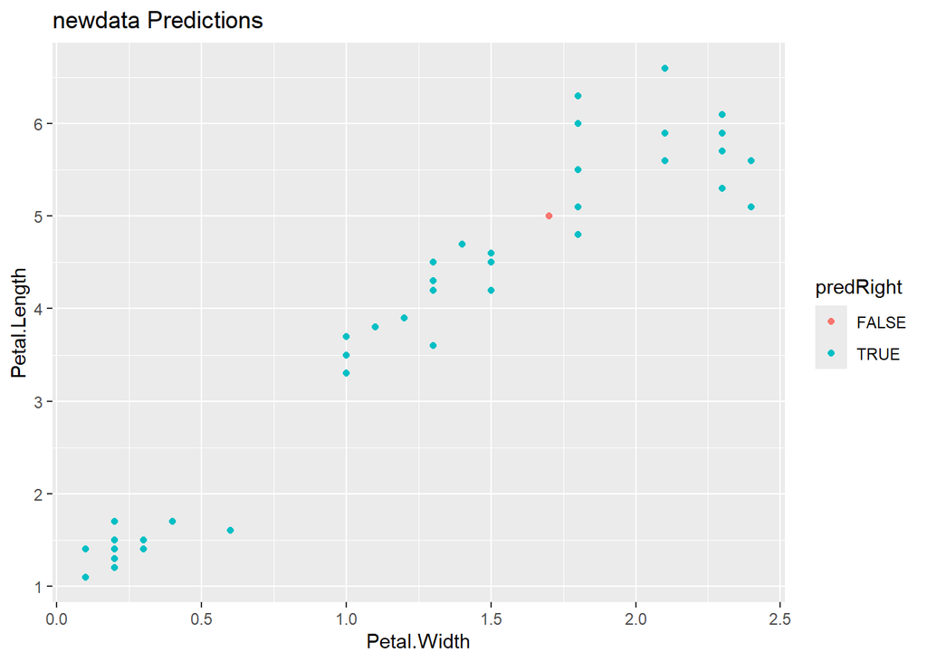

```r
qplot(Petal.Width, Petal.Length, colour = predRight, data = testing, main = "newdata Predictions")
```

## Notes and further reading

- Random forests are usually one of the two top performing algorithms along with boosting in prediction contests
- random forests are difficult to interpret but often **very accurate**
- Care should be taken to avoid overfitting (see [rfcv](http://cran.r-project.org/web/packages/randomForest/randomForest.pdf) funtion)
- [Random forests](http://www.stat.berkeley.edu/~breiman/RandomForests/cc_home.htm)
- [Random forest Wikipedia](http://en.wikipedia.org/wiki/Random_forest)
- [Elements of Statistical Learning](http://www-stat.stanford.edu/~tibs/ElemStatLearn/)

# Boosting

## Basic idea

1. Take lots of (possibly) weak predictors
2. Weight them and add them up
3. Get a stronger predictor

## Basic idea behind boosting

1. Start with a set of classifiers $h_1, \dots, h_k$
   - Examples: all possible trees, regression models, cutoffs, etc.
2. Create a classifier that combines classification functions: $f\left(x\right) = sgn\left(\sum_{i=1}^{k}{\alpha_ih_i\left(x\right)}\right)$
   - The goal is to *minimize error* (on training set)
   - Iterative, select one $h$ at each step
   - Calculate weights based on errors
   - Upweight missed classifications and select next $h$

## Boosting in R

- Boosting can be used with any subset of classifiers
- One large subclass is [*gradient boosting*](http://en.wikipedia.org/wiki/Gradient_boosting)
- `R` has multiple boosting libraries. Differences include the choice of basic classifications functions and combination rules: `gbm` (boosting with trees), `mboost` (model based boosting), `ada` (statistical boosting based on additive logistic regression), `gamBoost` (for boosting generalized additive models)
- Most of these are available in `caret` package

#### Wage example

```r
library(ISLR)
data(Wage)
library(ggplot2)
library(caret)
Wage <- subset(Wage, select = -c(logwage))
inTrain <- createDataPartition(y = Wage$wage, p = 0.7, list = FALSE)
training <- Wage[inTrain,]
testing <- Wage[-inTrain,]
```

```r
library(gbm)
modFit <- train(wage ~ ., method = "gbm", data = training, verbose = FALSE)
print(modFit)
```

```
## Stochastic Gradient Boosting
##
## 2102 samples
##    9 predictor
##
## No pre-processing
## Resampling: Bootstrapped (25 reps)
## Summary of sample sizes: 2102, 2102, 2102, 2102, 2102, 2102, ...
## Resampling results across tuning parameters:
##
##   interaction.depth  n.trees  RMSE      Rsquared   MAE
##   1                   50      35.33389  0.3087623  23.68514
##   1                  100      34.77446  0.3180638  23.29221
##   1                  150      34.66858  0.3204719  23.26038
##   2                   50      34.78422  0.3187638  23.25799
##   2                  100      34.63329  0.3217359  23.23192
##   2                  150      34.68981  0.3199979  23.33448
##   3                   50      34.69825  0.3197540  23.21102
##   3                  100      34.81908  0.3149799  23.43356
##   3                  150      35.05857  0.3074045  23.65627
##
## Tuning parameter 'shrinkage' was held constant at a value of 0.1
##
## Tuning parameter 'n.minobsinnode' was held constant at a value of 10
## RMSE was used to select the optimal model using the smallest value.
## The final values used for the model were n.trees = 100, interaction.depth =
##  2, shrinkage = 0.1 and n.minobsinnode = 10.
```

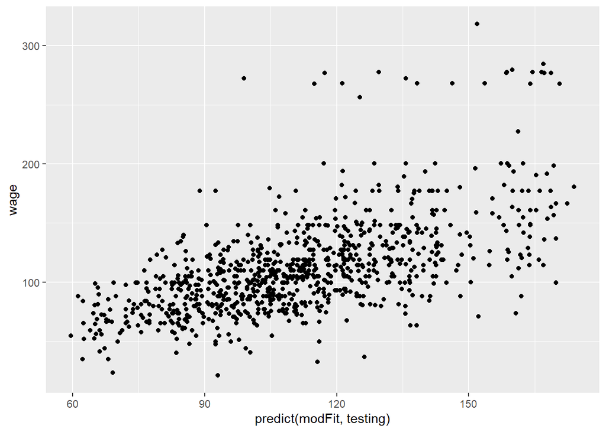

```r
qplot(predict(modFit, testing), wage, data = testing)
```

# Model based prediction

## Basic idea

1. Assume the data follow a probabilistic model
2. Use Bayes’ theorem to identify optimal classifiers

#### Pros

- Can take advantage of structure of the data
- May be computationally convenient
- Are reasonably accurate on real problems

#### Cons

- Make additional assumptions about the data
- When the model is incorrect you may get reduced accuracy

## Model based approach

1. The goal is to build *parametric* model for conditional distribution $\mathbb{P}\left(Y = k \vert X = x\right)$
2. A typical approach is to apply Bayes theorem:
   $$\mathbb{P}\left(Y = k \vert X = x\right) = \dfrac{\mathbb{P}\left(X = x
   \vert Y = k\right)\mathbb{P}\left(Y=k\right)}{\sum_{j =
   1}^{K}{\mathbb{P}\left(X = x \vert Y =
   j\right)\mathbb{P}\left(Y=j\right)}}$$
   $$\mathbb{P}\left(Y = k \vert X = x\right) =
   \dfrac{f_k\left(x\right)\pi_k}{\sum_{j = 1}^{K}{f_j\left(x\right)\pi_j}}$$
3. Typically prior probabilities $\pi_k$ are set **in advance**
4. A common choice for $f_k\left(x\right)$ is a Gaussian distribution: $f_k\left(x\right) = \dfrac{1}{\sigma_k\sqrt{2\pi}}e^{-\frac{\left(x-\mu_k\right)^2}{\sigma_k^2}}$
5. Estimate the parameters $\left(\mu_k, \sigma_k^2\right)$ from the data
6. Classify to the class with the highest value of $\mathbb{P}\left(Y=k \vert X = x\right)$

#### Classifying using the model

A range of models use this approach

- Linear discriminant analysis assumes $f_k\left(x\right)$ is multivariate Gaussian with same covariances
- Quadratic discriminant analysis assumes $f_k\left(x\right)$ is multivariate Gaussian with different covariances
- **Model based prediction** assumes more complicated versions of the covariance matrix
- Naive Bayes assumes independence between features for model building

#### Linear discriminant analysis

This is used because of the following relationship:

When we consider the (log) ratio of the probabilities of two classes:
$$log\left(\dfrac{\mathbb{P}\left(Y = k \vert X =
x\right)}{\mathbb{P}\left(Y = j \vert X = x\right)}\right) =
log\left(\dfrac{f_k\left(x\right)}{f_j\left(x\right)}\right) +
log\left(\dfrac{\pi_k}{\pi_j}\right)$$

Since the logarithm is a monotone function, it increases as the ratio increases. The relationship above also equals to

$$log\left(\dfrac{\pi_k}{\pi_j}\right) -
\dfrac{1}{2}\left(\mu_k+\mu_j\right)^T\Sigma^{-1}\left(\mu_k +
\mu_j\right) + x^T\Sigma^{-1}\left(\mu_k - \mu_j\right)$$

## Discriminant function

$$\delta_k\left(x\right) = x^T\Sigma^{-1}\mu_k -
\dfrac{1}{2}\mu_k\Sigma^{-1}\mu_k + log\left(\mu_k\right)$$

- Decide on class based on $\hat{Y}\left(x\right) = \max_{k}\left\{\delta_k\left(x\right)\right\}$
- We usually estimate parameters wih **Maximum Likelihood**

## Naive Bayes

The term *naive* is given to this method because we make an assumption: **independence** where this might not be the case in real life. Therefore, assuming independence we would have that

$$\mathbb{P}\left(Y = k \vert X_1, \dots, X_m\right) =
\dfrac{\pi_k\mathbb{P}\left(X_1, \dots, X_m\vert Y = k\right)}{\sum_{j =
1}^{K}{\mathbb{P}\left(X_1, \dots, X_m \vert Y = j\right)\pi_j}} \propto
\pi_k\mathbb{P}\left(X_1, \dots, X_m\vert Y = k\right)$$

Therefore

$$\mathbb{P}\left(X_1, \dots, X_m, Y = k\right) \approx \pi_k
\mathbb{P}\left(X_1\vert Y = k\right)\mathbb{P}\left(X_2\vert Y =
k\right) \dots \mathbb{P}\left(X_m\vert Y = k\right)$$

#### Iris data as an example

```r
data(iris)
library(ggplot2)
names(iris)
```

```
## [1] "Sepal.Length" "Sepal.Width"  "Petal.Length" "Petal.Width"  "Species"
```

```r
table(iris$Species)
```

```
##
##     setosa versicolor  virginica
##         50         50         50
```

```r
inTrain <- createDataPartition(y = iris$Species, p = 0.7, list = FALSE)
training <- iris[inTrain,]
testing <- iris[-inTrain,]
dim(training)
```

```
## [1] 105   5
```

```r
dim(testing)
```

```
## [1] 45  5
```

```r
model_lda <- train(Species ~., data = training, method = "lda")
model_nb <- train(Species ~., data = training, method = "nb")
plda <- predict(model_lda, testing)
pnb <- predict(model_nb, testing)
table(plda,pnb)
```

```
##             pnb
## plda         setosa versicolor virginica
##   setosa         15          0         0
##   versicolor      0         14         1
##   virginica       0          1        14
```

#### Comparison of results

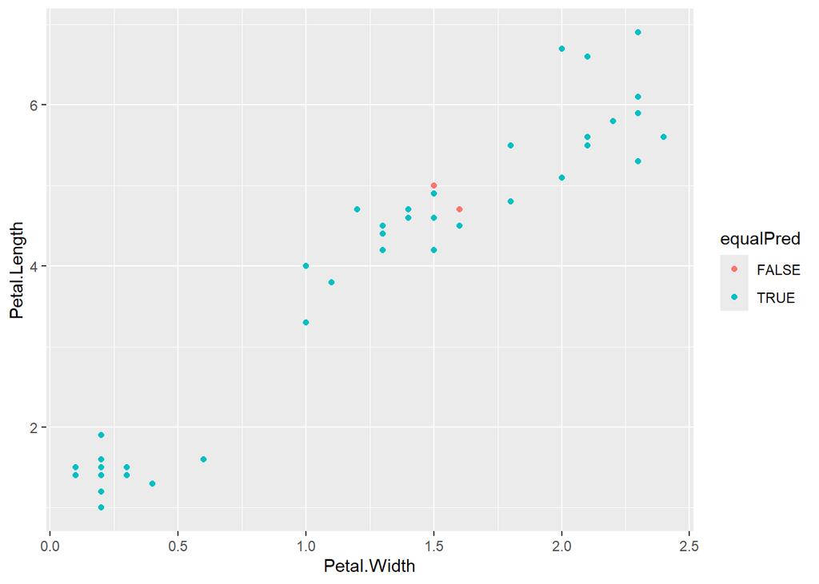

```r
equalPred <- (plda==pnb)
qplot(Petal.Width, Petal.Length, colour = equalPred, data = testing)
```

They perform very similarly.

**Note** all dataset from the `ElemStatLearn` can be downloaded from the page: https://hastie.su.domains/ElemStatLearn/datasets/